# Red wine dataset Anaysis by Rakesh

Red Wine data contains 1599 observation with 12 variables. Out of with 1 variable would be the responsible/output variable i.e quality and 11 variables are independent variable.

```
## [1] 1599   12
```

Following output contains the name of all the variable along with their datatype. So,all the independent variables are numeric in datatype and the response variable have integer data type.

```
## 'data.frame':    1599 obs. of  12 variables:
##  $ fixed.acidity       : num  7.4 7.8 7.8 11.2 7.4 7.4 7.9 7.3 7.8 7.5 ...
##  $ volatile.acidity    : num  0.7 0.88 0.76 0.28 0.7 0.66 0.6 0.65 0.58 0.5 ...
##  $ citric.acid         : num  0 0 0.04 0.56 0 0 0.06 0 0.02 0.36 ...
##  $ residual.sugar      : num  1.9 2.6 2.3 1.9 1.9 1.8 1.6 1.2 2 6.1 ...
##  $ chlorides           : num  0.076 0.098 0.092 0.075 0.076 0.075 0.069 0.065 0.073 0.071 ...
##  $ free.sulfur.dioxide : num  11 25 15 17 11 13 15 15 9 17 ...
##  $ total.sulfur.dioxide: num  34 67 54 60 34 40 59 21 18 102 ...
##  $ density             : num  0.998 0.997 0.997 0.998 0.998 ...
##  $ pH                  : num  3.51 3.2 3.26 3.16 3.51 3.51 3.3 3.39 3.36 3.35 ...
##  $ sulphates           : num  0.56 0.68 0.65 0.58 0.56 0.56 0.46 0.47 0.57 0.8 ...
##  $ alcohol             : num  9.4 9.8 9.8 9.8 9.4 9.4 9.4 10 9.5 10.5 ...
##  $ quality             : int  5 5 5 6 5 5 5 7 7 5 ...
```

Following the the summary of Red Wine quality data.

```
##  fixed.acidity   volatile.acidity  citric.acid    residual.sugar
##  Min.   : 4.60   Min.   :0.1200   Min.   :0.000   Min.   : 0.900
##  1st Qu.: 7.10   1st Qu.:0.3900   1st Qu.:0.090   1st Qu.: 1.900
##  Median : 7.90   Median :0.5200   Median :0.260   Median : 2.200
##  Mean   : 8.32   Mean   :0.5278   Mean   :0.271   Mean   : 2.539
##  3rd Qu.: 9.20   3rd Qu.:0.6400   3rd Qu.:0.420   3rd Qu.: 2.600
##  Max.   :15.90   Max.   :1.5800   Max.   :1.000   Max.   :15.500
##    chlorides       free.sulfur.dioxide total.sulfur.dioxide
##  Min.   :0.01200   Min.   : 1.00       Min.   :  6.00
##  1st Qu.:0.07000   1st Qu.: 7.00       1st Qu.: 22.00
##  Median :0.07900   Median :14.00       Median : 38.00
##  Mean   :0.08747   Mean   :15.87       Mean   : 46.47
##  3rd Qu.:0.09000   3rd Qu.:21.00       3rd Qu.: 62.00
##  Max.   :0.61100   Max.   :72.00       Max.   :289.00
##     density             pH          sulphates         alcohol
##  Min.   :0.9901   Min.   :2.740   Min.   :0.3300   Min.   : 8.40
##  1st Qu.:0.9956   1st Qu.:3.210   1st Qu.:0.5500   1st Qu.: 9.50
##  Median :0.9968   Median :3.310   Median :0.6200   Median :10.20
##  Mean   :0.9967   Mean   :3.311   Mean   :0.6581   Mean   :10.42
##  3rd Qu.:0.9978   3rd Qu.:3.400   3rd Qu.:0.7300   3rd Qu.:11.10
##  Max.   :1.0037   Max.   :4.010   Max.   :2.0000   Max.   :14.90
##     quality
##  Min.   :3.000
##  1st Qu.:5.000
##  Median :6.000
##  Mean   :5.636
##  3rd Qu.:6.000
##  Max.   :8.000
```

# Univariate Plots Section

Lets start to explore each variable that we have in dataset. Following are the name of the variables in provided dataset.

```
##  [1] "fixed.acidity"        "volatile.acidity"     "citric.acid"
##  [4] "residual.sugar"       "chlorides"            "free.sulfur.dioxide"
##  [7] "total.sulfur.dioxide" "density"              "pH"
## [10] "sulphates"            "alcohol"              "quality"
```

Lets start with the response or dependent variable.

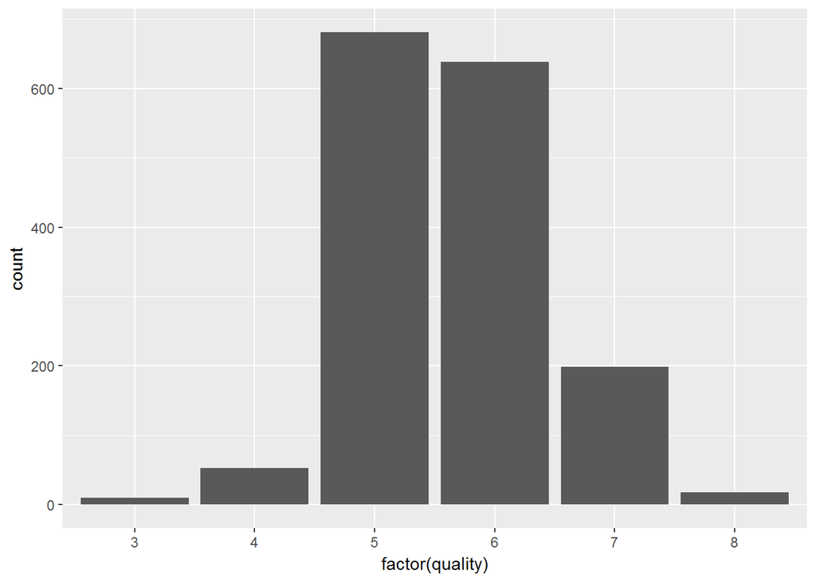

Above histogram shows the quality data is normally distributed.most of the wine are having quality number 5 or 6 and there are very few wines which are having worst quality i.e 3 and the best quality i.e 8

Lets confirm our observation about quality variable through the statistical data.

```
##    Min. 1st Qu.  Median    Mean 3rd Qu.    Max.
##   3.000   5.000   6.000   5.636   6.000   8.000
```

the above statistics cleary shows that mean of the quality is 5.636 , and same this we observed through the histogram for quality.

Now lets visualize the independent variable one by one. fixed.acidity volatile.acidity citric.acid residual.sugar chlorides free.sulfur.dioxide total.sulfur.dioxide density pH sulphates alcohol

lets start analysis independent variables , first with fixed.acidity. fixed.acidity is amount of non-volatile acid involved with the wine

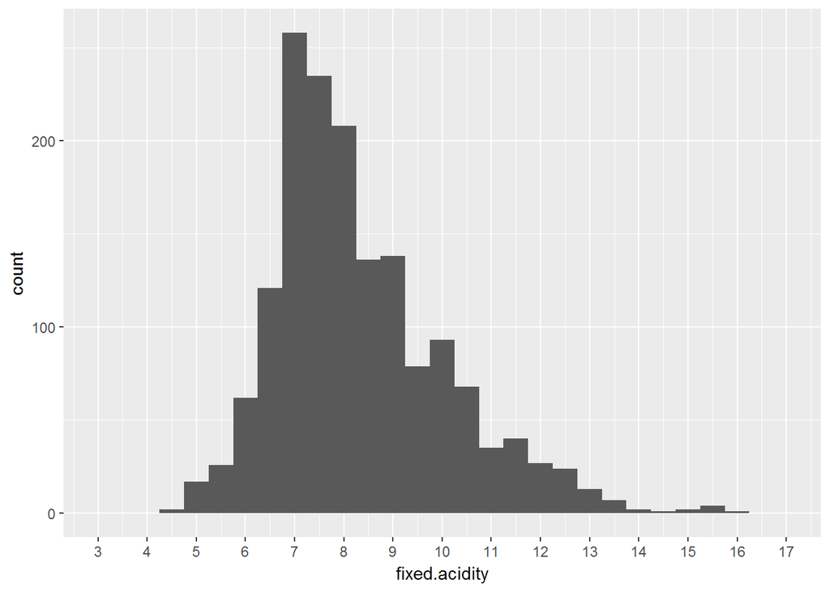

fixed.acidity distribution is seems to be kind of normally distributed with the most of fixed.acid involved in wine is between 7 to 8( g / dm^3) and there is a long tail at the right of the histogram.

Statistics for the fixed.acidity are as follows:

```
##    Min. 1st Qu.  Median    Mean 3rd Qu.    Max.
##    4.60    7.10    7.90    8.32    9.20   15.90
```

```
##
##  4.6  4.7  4.9    5  5.1  5.2  5.3  5.4  5.5  5.6  5.7  5.8  5.9    6  6.1
##    1    1    1    6    4    6    4    5    1   14    2    4    9   13   16
##  6.2  6.3  6.4  6.5  6.6  6.7  6.8  6.9    7  7.1  7.2  7.3  7.4  7.5  7.6
##   20   14   25   17   37   28   46   38   50   57   67   44   44   52   46
##  7.7  7.8  7.9    8  8.1  8.2  8.3  8.4  8.5  8.6  8.7  8.8  8.9    9  9.1
##   49   53   42   42   26   45   40   26   19   27   24   34   33   26   29
##  9.2  9.3  9.4  9.5  9.6  9.7  9.8  9.9   10 10.1 10.2 10.3 10.4 10.5 10.6
##   16   22   17   14   17    9   15   26   23   10   19   11   21   12   14
## 10.7 10.8 10.9   11 11.1 11.2 11.3 11.4 11.5 11.6 11.7 11.8 11.9   12 12.1
##   10   10    8    3    9    5    7    5   13   12    3    3   12    7    1
## 12.2 12.3 12.4 12.5 12.6 12.7 12.8 12.9   13 13.2 13.3 13.4 13.5 13.7 13.8
##    4    5    4    7    4    4    5    2    3    3    3    1    1    2    1
##   14 14.3   15 15.5 15.6 15.9
##    1    1    2    2    2    1
```

the above numbers are clearly showing that the fixed.acidity (non volatile acid involvement in wine) is bit positively skewed distributed with max and min as 15.90 and 4.60 respectively and mean of the fixed.acidity is 8.32 which seems to be more shifted towards the min value.but the histogram shows that fixed.acidity is skewed for only few records.lets analyse this

```
## [1] 0.01250782
```

Only 1.2% of data or the wine has fixed.acidity greater than 13.

Now lets visualize the top 98.8% of the data for fixed.acidity variable.

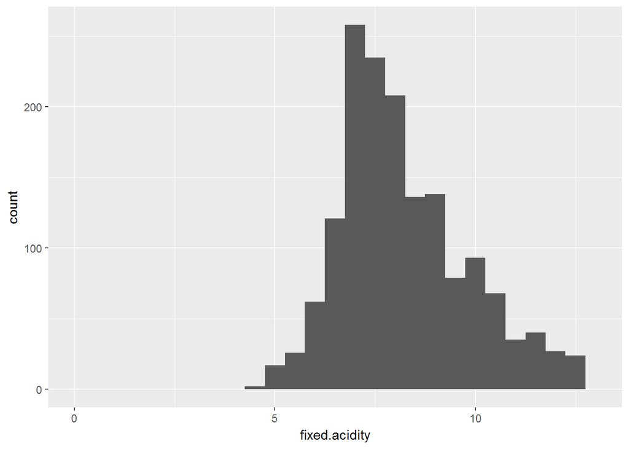

after clipping off top 1.25% of data now the distribution is seems to be quite normally distributed.

Now next independent variable to analysis is volatile.acidity.

Volatile.acidity: The amount of acetic acid in wine, which at too high of levels can lead to an unpleasant, vinegar taste

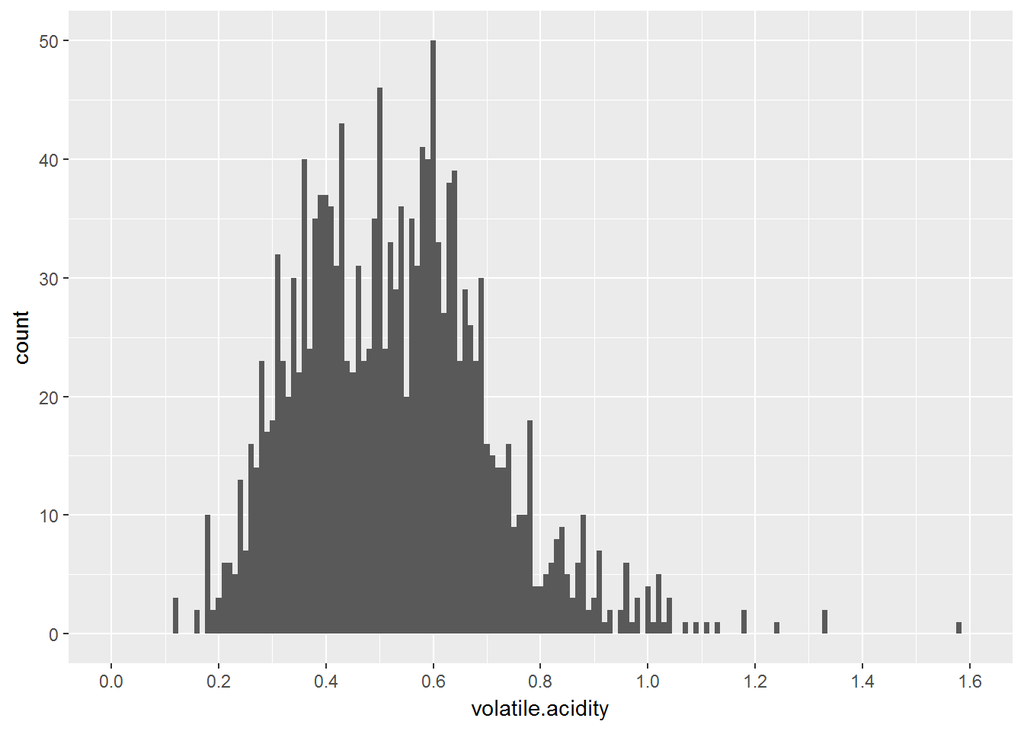

Frequency distribution for the volatile.acidity independent variable is also seems to be normal, Most of the frequency lie in middle of the histogram with tail at both end.

Following are the statistical number for the volatile.acidity variable.

```
##    Min. 1st Qu.  Median    Mean 3rd Qu.    Max.
##  0.1200  0.3900  0.5200  0.5278  0.6400  1.5800
```

```
##
##  0.12  0.16  0.18  0.19   0.2  0.21  0.22  0.23  0.24  0.25  0.26  0.27
##     3     2    10     2     3     6     6     5    13     7    16    14
##  0.28  0.29 0.295   0.3 0.305  0.31 0.315  0.32  0.33  0.34  0.35  0.36
##    23    16     1    16     2    30     2    23    20    30    22    38
## 0.365  0.37  0.38  0.39 0.395   0.4  0.41 0.415  0.42  0.43  0.44  0.45
##     2    24    35    35     2    37    33     3    31    43    23    22
##  0.46  0.47 0.475  0.48  0.49   0.5  0.51  0.52  0.53  0.54 0.545  0.55
##    31    21     2    24    35    46    24    33    29    31     5    20
##  0.56 0.565  0.57 0.575  0.58 0.585  0.59 0.595   0.6 0.605  0.61 0.615
##    34     1    28     3    38     3    39     1    47     3    27     6
##  0.62 0.625  0.63 0.635  0.64 0.645  0.65 0.655  0.66 0.665  0.67 0.675
##    24     3    29     9    27    12    16     7    26     3    23     3
##  0.68 0.685  0.69 0.695   0.7 0.705  0.71 0.715  0.72 0.725  0.73 0.735
##    12    11    23     7    10     6     3    12     5     9     6     8
##  0.74 0.745  0.75 0.755  0.76 0.765  0.77 0.775  0.78 0.785  0.79 0.795
##    11     5     6     3     5     5     6     4    10     8     2     2
##   0.8 0.805  0.81 0.815  0.82 0.825  0.83 0.835  0.84 0.845  0.85 0.855
##     3     1     2     3     5     1     4     4     8     1     2     3
##  0.86 0.865  0.87 0.875  0.88 0.885  0.89 0.895   0.9  0.91 0.915  0.92
##     2     1     4     2     5     5     1     1     3     3     4     1
## 0.935  0.95 0.955  0.96 0.965 0.975  0.98     1 1.005  1.01  1.02 1.025
##     2     1     1     3     3     1     3     3     1     1     4     1
## 1.035  1.04  1.07  1.09 1.115  1.13  1.18 1.185  1.24  1.33  1.58
##     1     3     1     1     1     1     1     1     1     2     1
```

The summary of volatile.acidity variable clearly shows that the mean 0.5278 which lie between the max and min value of valotile.acidity.

Third independent variable in the row is citric.acid

citric.acid:found in small quantities, citric acid can add ‘freshness’ and flavor to wines

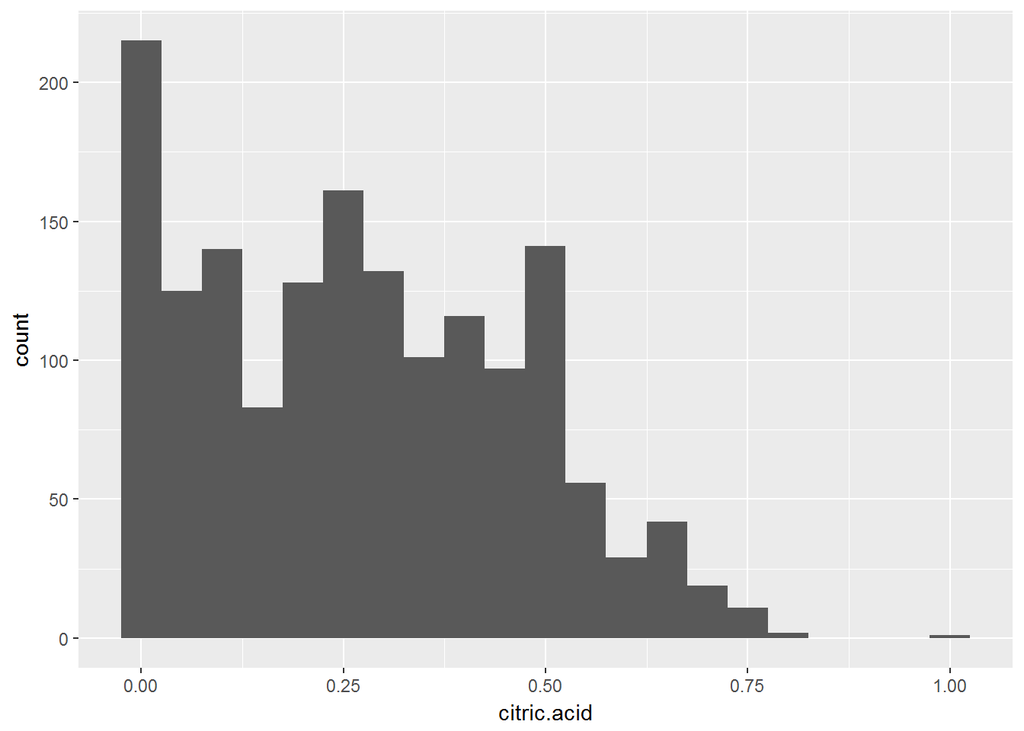

distribution for the citric acid is seems to be skewed.

lets visualize the same distribution after transforming citric.acid variable to square root citric.acid value

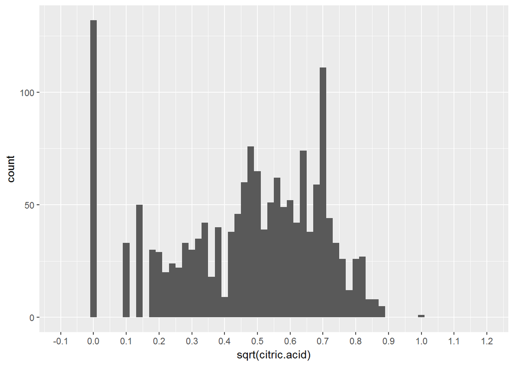

Above histogram is seems to have a long tail at the left of the histogram hence it is left skewed(negatively skewed) ,with an outlier at 0 which has the maximum frequency.

lets check the statistics of data

```
##    Min. 1st Qu.  Median    Mean 3rd Qu.    Max.
##   0.000   0.090   0.260   0.271   0.420   1.000
```

```
##
##    0 0.01 0.02 0.03 0.04 0.05 0.06 0.07 0.08 0.09  0.1 0.11 0.12 0.13 0.14
##  132   33   50   30   29   20   24   22   33   30   35   15   27   18   21
## 0.15 0.16 0.17 0.18 0.19  0.2 0.21 0.22 0.23 0.24 0.25 0.26 0.27 0.28 0.29
##   19    9   16   22   21   25   33   27   25   51   27   38   20   19   21
##  0.3 0.31 0.32 0.33 0.34 0.35 0.36 0.37 0.38 0.39  0.4 0.41 0.42 0.43 0.44
##   30   30   32   25   24   13   20   19   14   28   29   16   29   15   23
## 0.45 0.46 0.47 0.48 0.49  0.5 0.51 0.52 0.53 0.54 0.55 0.56 0.57 0.58 0.59
##   22   19   18   23   68   20   13   17   14   13   12    8    9    9    8
##  0.6 0.61 0.62 0.63 0.64 0.65 0.66 0.67 0.68 0.69  0.7 0.71 0.72 0.73 0.74
##    9    2    1   10    9    7   14    2   11    4    2    1    1    3    4
## 0.75 0.76 0.78 0.79    1
##    1    3    1    1    1
```

lets explore the next 3 variable.

residual.sugar:the amount of sugar remaining after fermentation stops, it’s rare to find wines with less than 1 gram/liter and wines with greater than 45 grams/liter are considered sweet.

chlorides:the amount of salt in the wine

free.sulfur.dioxide:the free form of SO2 exists in equilibrium between molecular SO2 (as a dissolved gas) and bisulfite ion; it prevents microbial growth and the oxidation of wine

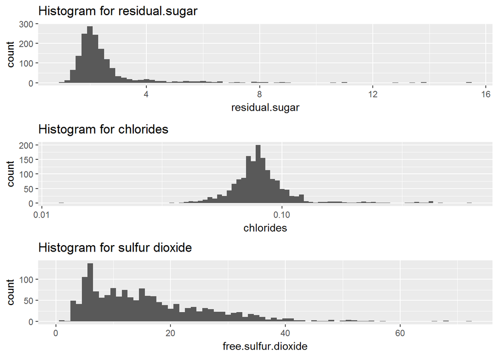

Residual.sugar is seems to be normally distributed for most of the data , but with a long tail of low height on right side. chlorides is normally distributed with the outlier on the right. free.sulfur.dioxide is positively skewed or right skewed.

lets have a look on the statistical summary for these 3 independent variables.

```
##  residual.sugar     chlorides       free.sulfur.dioxide
##  Min.   : 0.900   Min.   :0.01200   Min.   : 1.00
##  1st Qu.: 1.900   1st Qu.:0.07000   1st Qu.: 7.00
##  Median : 2.200   Median :0.07900   Median :14.00
##  Mean   : 2.539   Mean   :0.08747   Mean   :15.87
##  3rd Qu.: 2.600   3rd Qu.:0.09000   3rd Qu.:21.00
##  Max.   :15.500   Max.   :0.61100   Max.   :72.00
```

for residual.sugar it seems that there is large difference between the max value and the mean of the distribution, and mean seems to be shifted more towards the min value. but when we visualize the same thing on histogram , it seems there were only few wines which have more sugar residual.same thing can be observed by below output. it clealry shows that there are very few wines which have residual.sugar more than four.

```
##
##  0.9  1.2  1.3  1.4  1.5  1.6 1.65  1.7 1.75  1.8  1.9    2 2.05  2.1 2.15
##    2    8    5   35   30   58    2   76    2  129  117  156    2  128    2
##  2.2 2.25  2.3 2.35  2.4  2.5 2.55  2.6 2.65  2.7  2.8 2.85  2.9 2.95    3
##  131    1  109    1   86   84    1   79    1   39   49    1   24    1   25
##  3.1  3.2  3.3  3.4 3.45  3.5  3.6 3.65  3.7 3.75  3.8  3.9    4  4.1  4.2
##    7   15   11   15    1    2    8    1    4    1    8    6   11    6    5
## 4.25  4.3  4.4  4.5  4.6 4.65  4.7  4.8    5  5.1 5.15  5.2  5.4  5.5  5.6
##    1    8    4    4    6    2    1    3    1    5    1    3    1    8    6
##  5.7  5.8  5.9    6  6.1  6.2  6.3  6.4 6.55  6.6  6.7    7  7.2  7.3  7.5
##    1    4    3    4    4    3    2    3    2    2    2    1    1    1    1
##  7.8  7.9  8.1  8.3  8.6  8.8  8.9    9 10.7   11 12.9 13.4 13.8 13.9 15.4
##    2    3    2    3    1    2    1    1    1    2    1    1    2    1    2
## 15.5
##    1
```

only 7.8% of wine has sugar.residual greater than 4.we can also visualize residual.sugar variable but cutting off top 7.8% of data , but i am parking it now till the statistical observation comments on remaining 2 variables.

```
## [1] 0.07817386
```

Chloride: Cholride statistical data is also converying the same thing as of residual.sugar, that the distribution is positively skewed. but the histogram suggest that distribution is normal apart from some outlier and also no body would prefer the very salty wine.

free.sulfur.dioxide: for this variable both visiualization and statistics are complementing each other , both techniques are converying the same thing is free.sulfur.dioxide distribution is positively skewed or right skewed.

Now as promised , we can cut off top 7.8% of data and then visiualize the residual.sugar distribution.

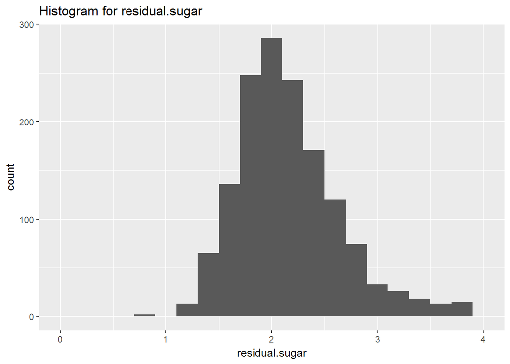

after removing top 7.8% of data , the residual.sugar distribution seems to be normally distributed.

Now lets move to next there independent variables.

total.sulfur.dioxide:amount of free and bound forms of S02; in low concentrations, SO2 is mostly undetectable in wine, but at free SO2 concentrations over 50 ppm, SO2 becomes evident in the nose and taste of wine.

density:the density of water is close to that of water depending on the percent alcohol and sugar content.

pH:describes how acidic or basic a wine is on a scale from 0 (very acidic) to 14(very basic), most wines are between 3-4 on the pH scale

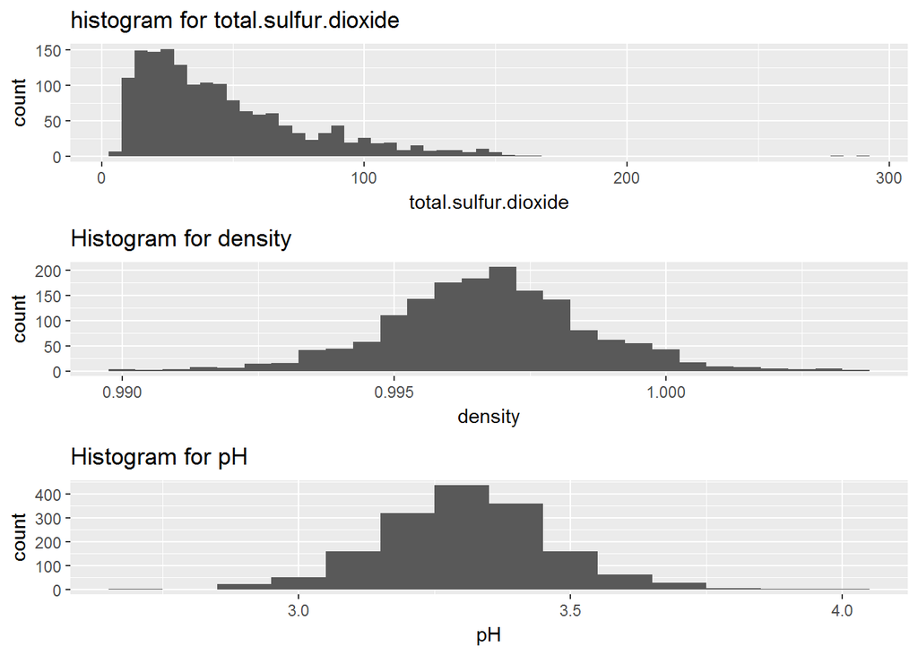

total.sulfur.dioxide is seems to be positively skewed distribution has long tail at the right side of distribution.

density is clearly normally distributed.

ph is also with nice bar climbing up and from 3.0 and reach to top of frequency and then again started climbing down well before 3.5. hence ph is also normally distributed.

now lets check whats satistics say about our visiual observations.

```
##  num [1:1599] 34 67 54 60 34 40 59 21 18 102 ...
```

```
##  num [1:1599] 3.51 3.2 3.26 3.16 3.51 3.51 3.3 3.39 3.36 3.35 ...
```

```
##  total.sulfur.dioxide    density             pH
##  Min.   :  6.00       Min.   :0.9901   Min.   :2.740
##  1st Qu.: 22.00       1st Qu.:0.9956   1st Qu.:3.210
##  Median : 38.00       Median :0.9968   Median :3.310
##  Mean   : 46.47       Mean   :0.9967   Mean   :3.311
##  3rd Qu.: 62.00       3rd Qu.:0.9978   3rd Qu.:3.400
##  Max.   :289.00       Max.   :1.0037   Max.   :4.010
```

This time the statistics and visiualization are conveying the same thing 1. total.sulfur.dioxide is positively skewed distribution. 2. density is normal distributed same is visible through the histogram and statistics. 3. pH is also normally distributed and both histogram and statistics supports this.

Now we have two sulfur.dioxide independent variable , one variable is contains free form of sulphur amount and other variable contains the total sulfur dioxide amount(free + bounds form of sulphur),we can also create another variable which shows only the bound form of sulphur. lets create it and anlayze its distribution.

Now lets visiualize the frequency distribution for bound sulfur dioxide.

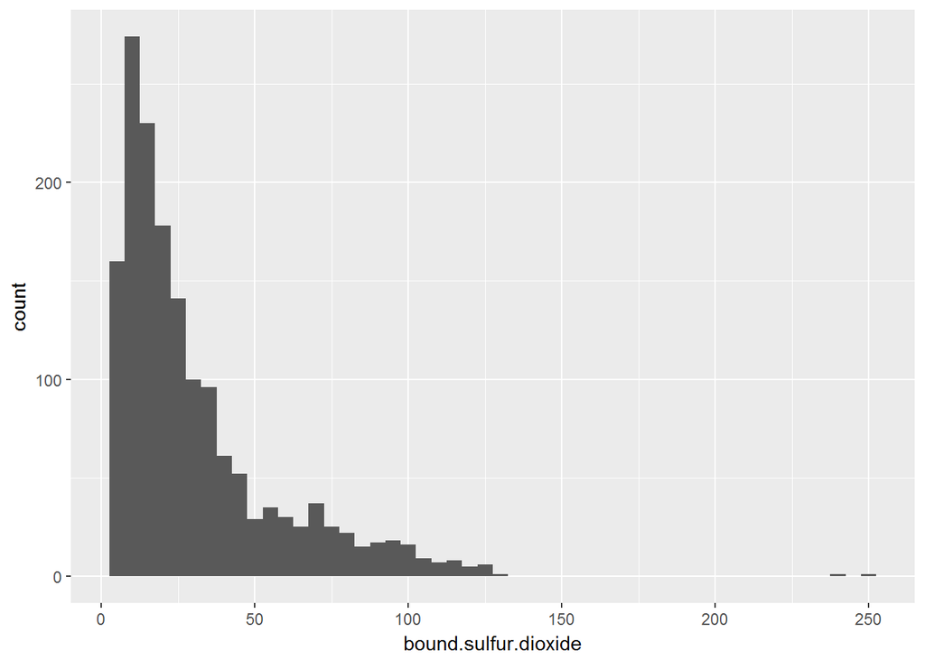

distribution for bounded form of sulphur dioxide is also positively skewed or right skewed.

we have now reached the last 2 independent variables.

1.sulphates: a wine additive which can contribute to sulfur dioxide gas (S02) levels, wich acts as an antimicrobial and antioxidant.

2.alcohol: the percent alcohol content of the wine

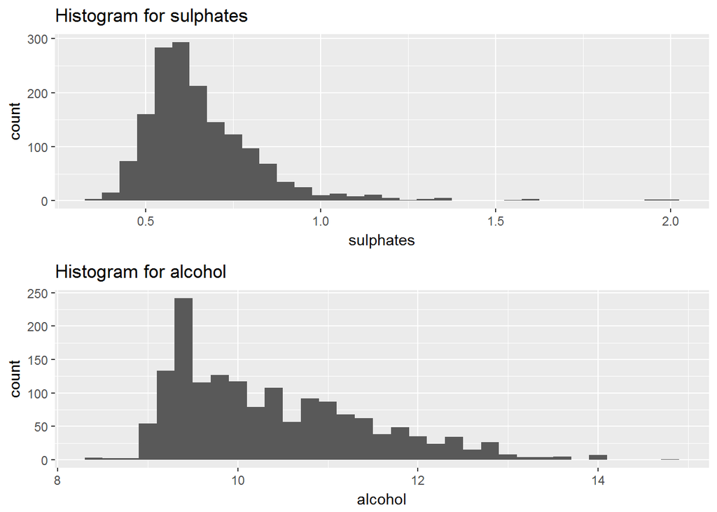

Mostly sulphates is normally distributed. apart from some of the wine with more sulphate.

lets check how many wines are with sulphates more than 1.0.

```
## [1] 0.03627267
```

only 3.6 % of the wines are having sulphates more than 1 .

alcohol distribution is positively skewed or right skewed.

lets check the statistics data for sulphates and alcohol variable.

```
##    sulphates         alcohol
##  Min.   :0.3300   Min.   : 8.40
##  1st Qu.:0.5500   1st Qu.: 9.50
##  Median :0.6200   Median :10.20
##  Mean   :0.6581   Mean   :10.42
##  3rd Qu.:0.7300   3rd Qu.:11.10
##  Max.   :2.0000   Max.   :14.90
```

From statistic value it seems mean is more shifted towards the minimum value for both sulphates and alcohol.but for sulphates as we have seen in the histogram that only 3.6% of wine are having sulphate value more than 1.

If we visualize top 96.4% of data for sulphate, then the distribution should be normal. its visiualize it.

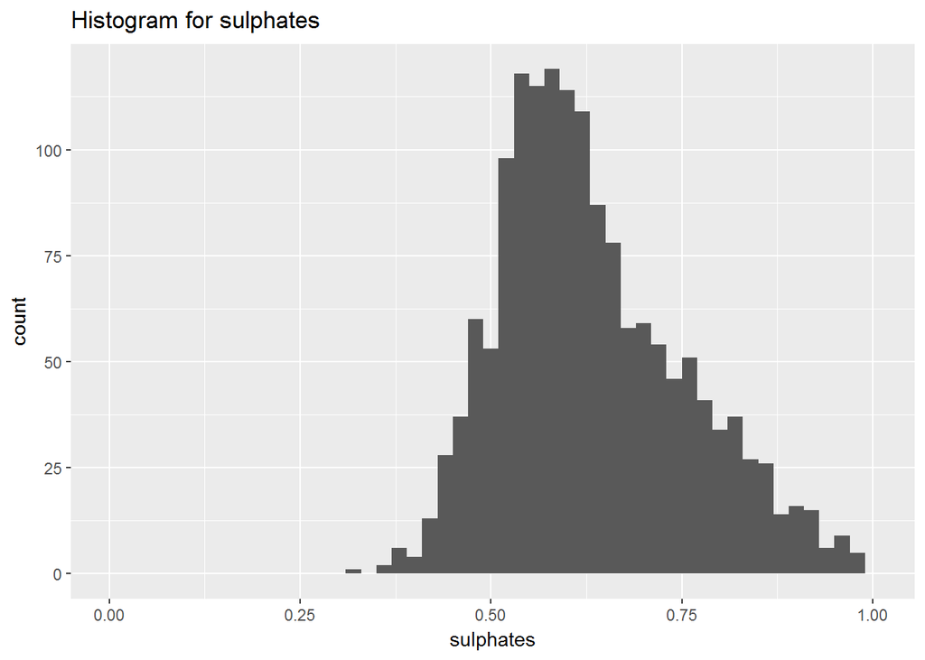

for top 96.4% of data frequency distribution is quite normalnow with bit skewedness on right side of distribution.

# Univariate Analysis:

### What is the structure of your dataset?

There are 1599 observation 12 variable (1 output/based/dependent variable and 11 independent/input variables.) in the red wine dataset.All the variables in my observation are numeric except output variable quality which is of int data type.

### What is/are the main feature(s) of interest in your dataset?

In my observation of univarite dataset it seems that following features could drive the quality of wine.

Features are:

1. volatile.acidity.
2. chlorides.
3. density.
4. pH.

why i choose only the above 4 variable , is because the fequency distribution for these variables are normal as the quality of wine.

### What other features in the dataset do you think will help support your

### investigation into your feature(s) of interest?

There some other features that could help my investigation are :

1. fixed.acidity.
2. residual.sugar.
3. sulphates.

Also i would really like to see is amount of alcohol and total.sulfur.dioxide is also a determining factor in wine quality.

### Did you create any new variables from existing variables in the dataset?

Yes, I have created a new variable called bound.sulfur.dioxide from total.sulfur.dioxide and free.sulfur.dioxide. but its distribution is not different from total.sulfur.dioxide and free.sulfur.dioxide. i don’t think this variable would give different insight to the distributions from total.sulfur.dioxide and free.sulfur.dioxide.

### Of the features you investigated, were there any unusual distributions?

There were few distribution which seems to be normally distributed but having a long tail on right side of distribution.so to determine whether the distribution is normal or skewed, some portion of the data for those variable has been clipped off. After clipping off some portion of data , the distribution has been more normal. following are the variable which shows the normal distribution after clipping of some portion of the data.

1. fixed.acidity
2. residual.sugar
3. sulphates.

for clipping of some portion of data from the distribution , xlim with quantile parameter has been used.

# Bivariate Plots Section

lets start bivarite plot exploration by checking the correlation between all the variable in the dataset.

```
##                      fixed.acidity volatile.acidity citric.acid
## fixed.acidity           1.00000000     -0.256130895  0.67170343
## volatile.acidity       -0.25613089      1.000000000 -0.55249568
## citric.acid             0.67170343     -0.552495685  1.00000000
## residual.sugar          0.11477672      0.001917882  0.14357716
## chlorides               0.09370519      0.061297772  0.20382291
## free.sulfur.dioxide    -0.15379419     -0.010503827 -0.06097813
## total.sulfur.dioxide   -0.11318144      0.076470005  0.03553302
## density                 0.66804729      0.022026232  0.36494718
## pH                     -0.68297819      0.234937294 -0.54190414
## sulphates               0.18300566     -0.260986685  0.31277004
## alcohol                -0.06166827     -0.202288027  0.10990325
## quality                 0.12405165     -0.390557780  0.22637251
## bound.sulfur.dioxide   -0.07814929      0.097033939  0.06677604
##                      residual.sugar    chlorides free.sulfur.dioxide
## fixed.acidity           0.114776724  0.093705186        -0.153794193
## volatile.acidity        0.001917882  0.061297772        -0.010503827
## citric.acid             0.143577162  0.203822914        -0.060978129
## residual.sugar          1.000000000  0.055609535         0.187048995
## chlorides               0.055609535  1.000000000         0.005562147
## free.sulfur.dioxide     0.187048995  0.005562147         1.000000000
## total.sulfur.dioxide    0.203027882  0.047400468         0.667666450
## density                 0.355283371  0.200632327        -0.021945831
## pH                     -0.085652422 -0.265026131         0.070377499
## sulphates               0.005527121  0.371260481         0.051657572
## alcohol                 0.042075437 -0.221140545        -0.069408354
## quality                 0.013731637 -0.128906560        -0.050656057
## bound.sulfur.dioxide    0.174529035  0.055479649         0.425148917
##                      total.sulfur.dioxide     density          pH
## fixed.acidity                 -0.11318144  0.66804729 -0.68297819
## volatile.acidity               0.07647000  0.02202623  0.23493729
## citric.acid                    0.03553302  0.36494718 -0.54190414
## residual.sugar                 0.20302788  0.35528337 -0.08565242
## chlorides                      0.04740047  0.20063233 -0.26502613
## free.sulfur.dioxide            0.66766645 -0.02194583  0.07037750
## total.sulfur.dioxide           1.00000000  0.07126948 -0.06649456
## density                        0.07126948  1.00000000 -0.34169933
## pH                            -0.06649456 -0.34169933  1.00000000
## sulphates                      0.04294684  0.14850641 -0.19664760
## alcohol                       -0.20565394 -0.49617977  0.20563251
```

[output cut: 15 more lines]

```
## bound.sulfur.dioxide  0.032244043 -0.22320257 -0.20546298
##                      bound.sulfur.dioxide
## fixed.acidity                 -0.07814929
## volatile.acidity               0.09703394
## citric.acid                    0.06677604
## residual.sugar                 0.17452903
## chlorides                      0.05547965
## free.sulfur.dioxide            0.42514892
## total.sulfur.dioxide           0.95768634
## density                        0.09513464
## pH                            -0.10805328
## sulphates                      0.03224404
## alcohol                       -0.22320257
## quality                       -0.20546298
## bound.sulfur.dioxide           1.00000000
```

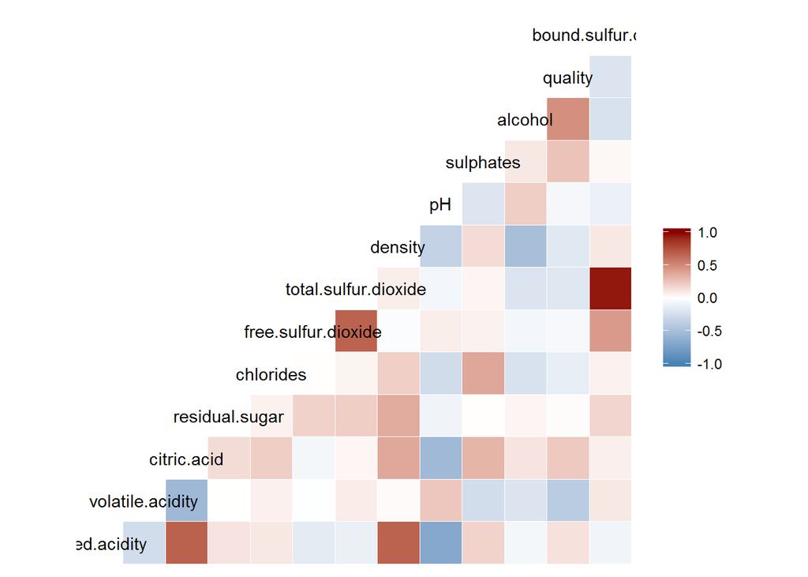

From the above plot and the correlation between each variable. it seems that none of the independent variable is highly co-related with the quality of the wine.but still i would like to analysis quality co-relation with the following independent variables. 1.Alcohol 2.fixed.acidity 3.citric.acid 4.residual.sugar 5.sulphates

all the above listed independent variables are having positive co-relation with quality , even it is weak.

if we look at the correlation between the independent variable.It seems there is also moderate corelation between fixed.acidity and density and obviously between the total.sulfur.dioxide and bound.sulfur.dioxide(variable created during the univariate analysis)

lets start our bivariate analysis visualization with Quality vs Alcohol

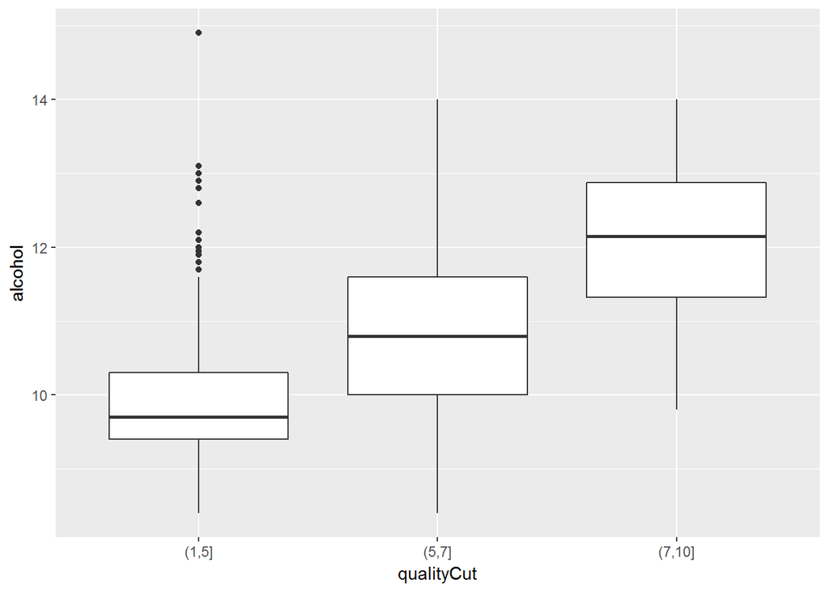

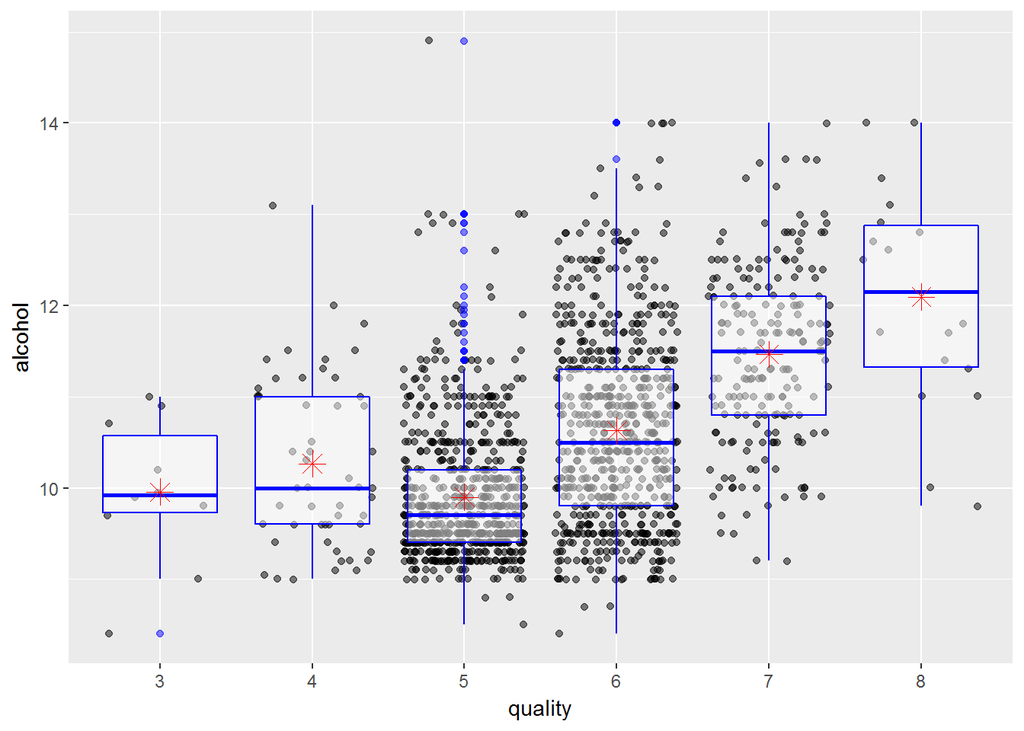

the above point chart shows that with the increase in the amount of alcohol the quality of wine is also increases.but this relationship is not perfectly linear

lets analyze the linear model for alcohol vs quality plot.

```
##
## Call:
## lm(formula = quality ~ alcohol, data = wineQualityDataset)
##
## Residuals:
##     Min      1Q  Median      3Q     Max
## -2.8442 -0.4112 -0.1690  0.5166  2.5888
##
## Coefficients:
##             Estimate Std. Error t value Pr(>|t|)
## (Intercept)  1.87497    0.17471   10.73   <2e-16 ***
## alcohol      0.36084    0.01668   21.64   <2e-16 ***
## ---
## Signif. codes:  0 '***' 0.001 '**' 0.01 '*' 0.05 '.' 0.1 ' ' 1
##
## Residual standard error: 0.7104 on 1597 degrees of freedom
## Multiple R-squared:  0.2267, Adjusted R-squared:  0.2263
## F-statistic: 468.3 on 1 and 1597 DF,  p-value: < 2.2e-16
```

Although linear model shows that the alcohol is a significant predictor for the quality.Yet the multiple R- square value show that only 23% of the variance in quality can be explained by the predictor variable alcohol.

Now lets move to the next pair quality vs fixed.acidity

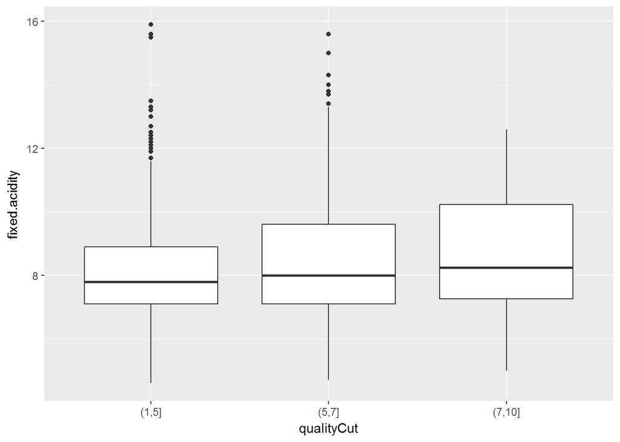

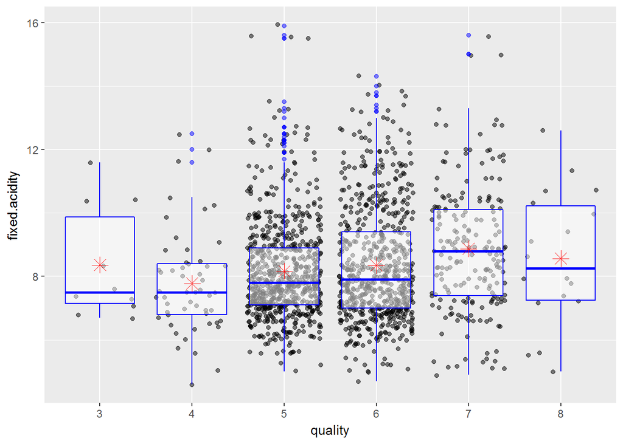

Linear model linear in above plot shows that with increase in the fixed.acidity the quality of wine do increase between the realtionship between the predictive and reponse variable in not exactly linear.

following is the linear model output for quality and fixed.acidity.

```
##
## Call:
## lm(formula = quality ~ fixed.acidity, data = wineQualityDataset)
##
## Residuals:
##     Min      1Q  Median      3Q     Max
## -2.8248 -0.6061  0.1925  0.4341  2.5550
##
## Coefficients:
##               Estimate Std. Error t value Pr(>|t|)
## (Intercept)    5.15732    0.09789  52.684  < 2e-16 ***
## fixed.acidity  0.05754    0.01152   4.996  6.5e-07 ***
## ---
## Signif. codes:  0 '***' 0.001 '**' 0.01 '*' 0.05 '.' 0.1 ' ' 1
##
## Residual standard error: 0.8016 on 1597 degrees of freedom
## Multiple R-squared:  0.01539,    Adjusted R-squared:  0.01477
## F-statistic: 24.96 on 1 and 1597 DF,  p-value: 6.496e-07
```

From above output , it is clearly visible that fixed.acidity is quite significant determining the quality of wine. but only 1.5 percent of variation in quality of wine is explained by fixed.acidity variable.

lets analysis the variable between quality vs citric.acid

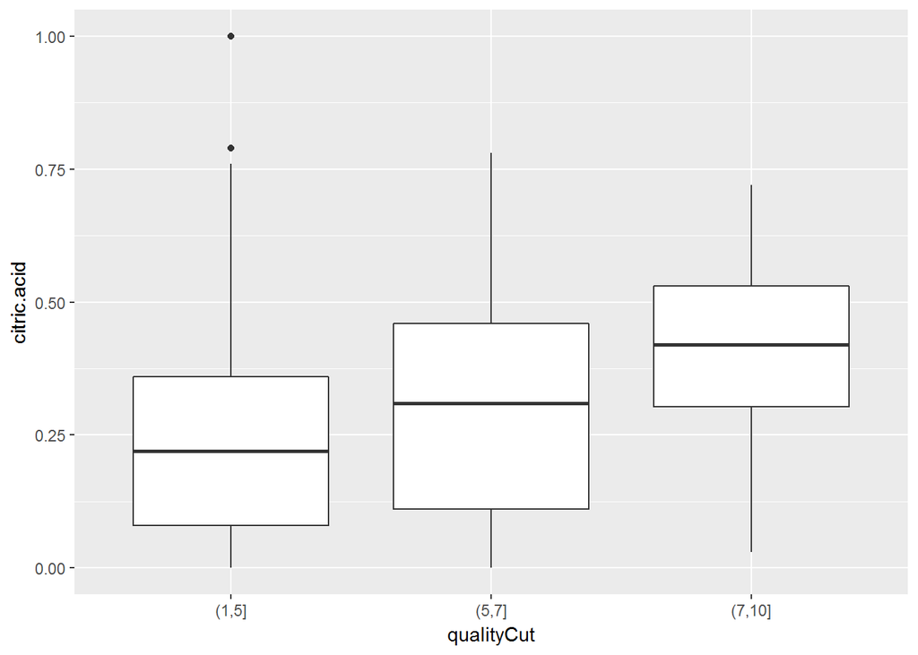

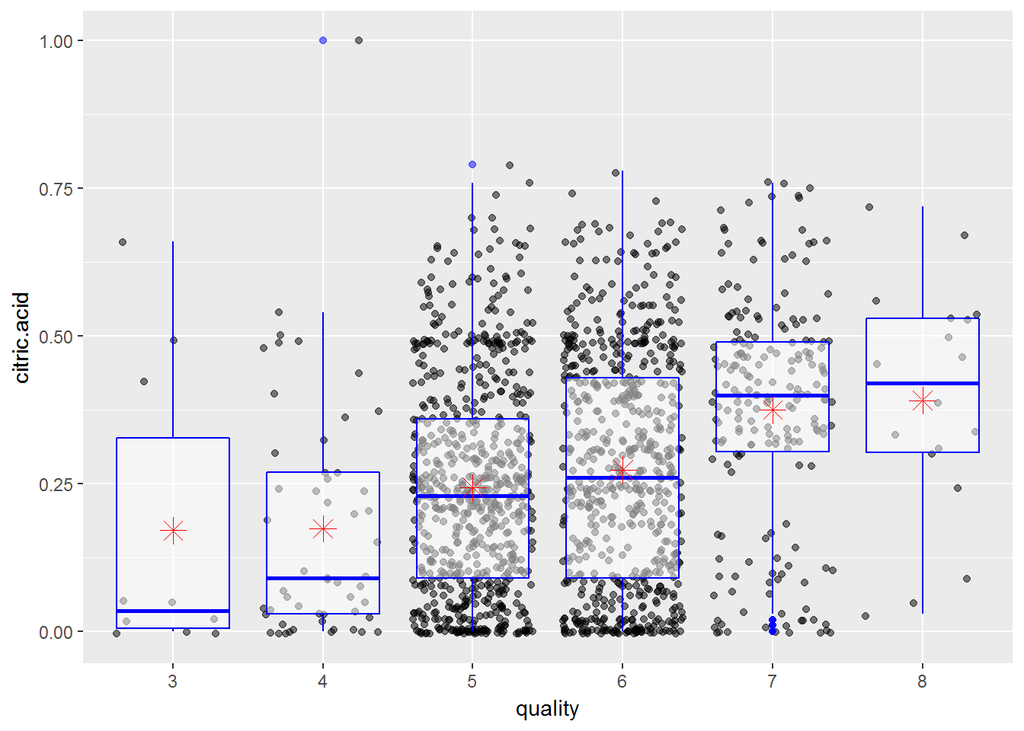

Above plot shows that with increase in the citric.acid the quality of wine do increase ,but the realtionship between the predictive and reponse variable in not exactly linear.

following is the linear model output for quality and citric.acid

```
##
## Call:
## lm(formula = quality ~ citric.acid, data = wineQualityDataset)
##
## Residuals:
##     Min      1Q  Median      3Q     Max
## -3.0011 -0.5976  0.1021  0.5057  2.5901
##
## Coefficients:
##             Estimate Std. Error t value Pr(>|t|)
## (Intercept)  5.38172    0.03372 159.610   <2e-16 ***
## citric.acid  0.93845    0.10104   9.288   <2e-16 ***
## ---
## Signif. codes:  0 '***' 0.001 '**' 0.01 '*' 0.05 '.' 0.1 ' ' 1
##
## Residual standard error: 0.7869 on 1597 degrees of freedom
## Multiple R-squared:  0.05124,    Adjusted R-squared:  0.05065
## F-statistic: 86.26 on 1 and 1597 DF,  p-value: < 2.2e-16
```

citric.acid is also seems to be quite significant to determine the quality of wine,but only 5% of the quality variance is explained by citric.acid.

Our next in line bivariate analysis is on quality vs residual.sugar

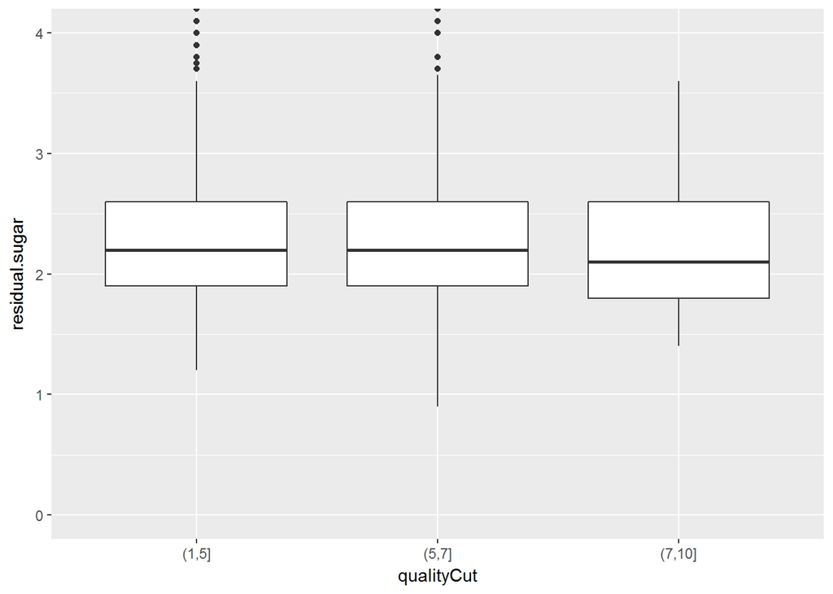

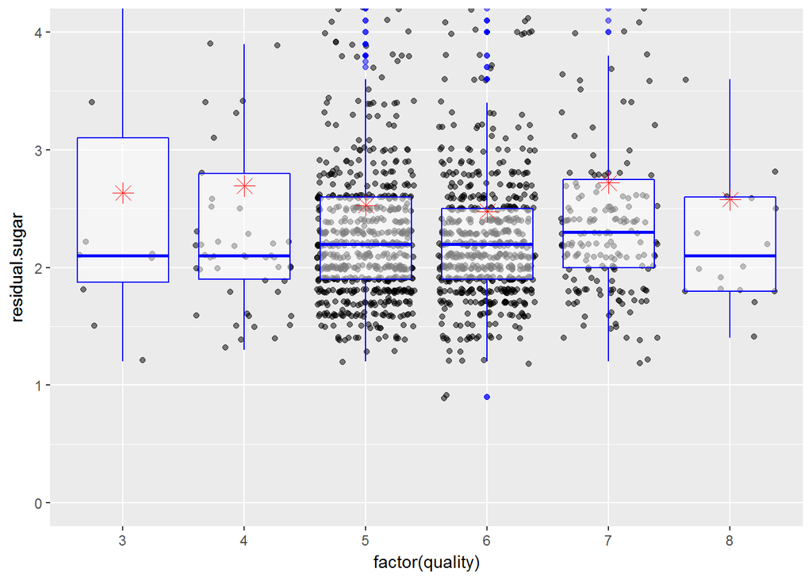

It seems there is no impact on the quality of wine with the change on the residual.sugar quantity.

```
##
## Call:
## lm(formula = quality ~ residual.sugar, data = wineQualityDataset)
##
## Residuals:
##     Min      1Q  Median      3Q     Max
## -2.6609 -0.6334  0.3580  0.3690  2.3729
##
## Coefficients:
##                Estimate Std. Error t value Pr(>|t|)
## (Intercept)    5.616055   0.041616 134.950   <2e-16 ***
## residual.sugar 0.007865   0.014331   0.549    0.583
## ---
## Signif. codes:  0 '***' 0.001 '**' 0.01 '*' 0.05 '.' 0.1 ' ' 1
##
## Residual standard error: 0.8077 on 1597 degrees of freedom
## Multiple R-squared:  0.0001886,  Adjusted R-squared:  -0.0004375
## F-statistic: 0.3012 on 1 and 1597 DF,  p-value: 0.5832
```

Residual.sugar is not significant to determine the quality of wine. it is having f-statistic less than 1 , which clearly shows that variable is not significant at all.

lets analyze the last pair that we choosed to plot, the pair is quality vs sulphur

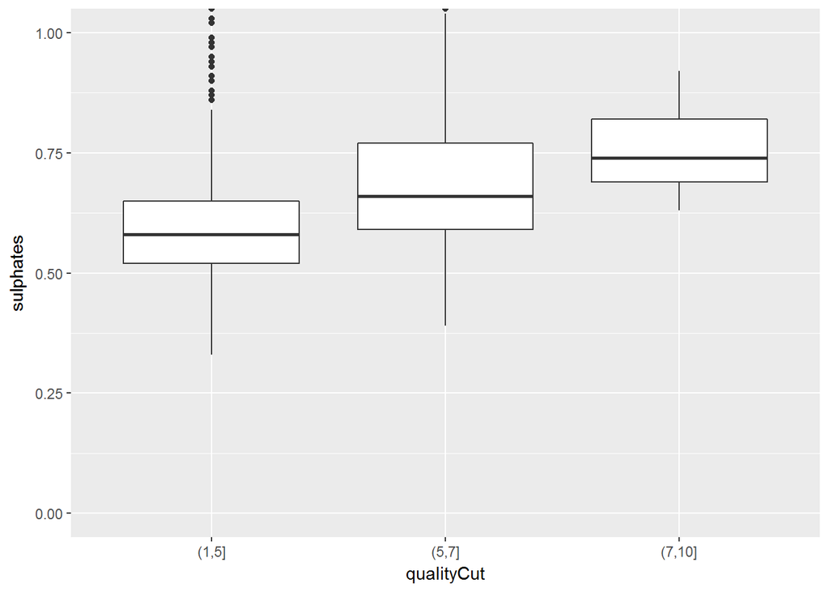

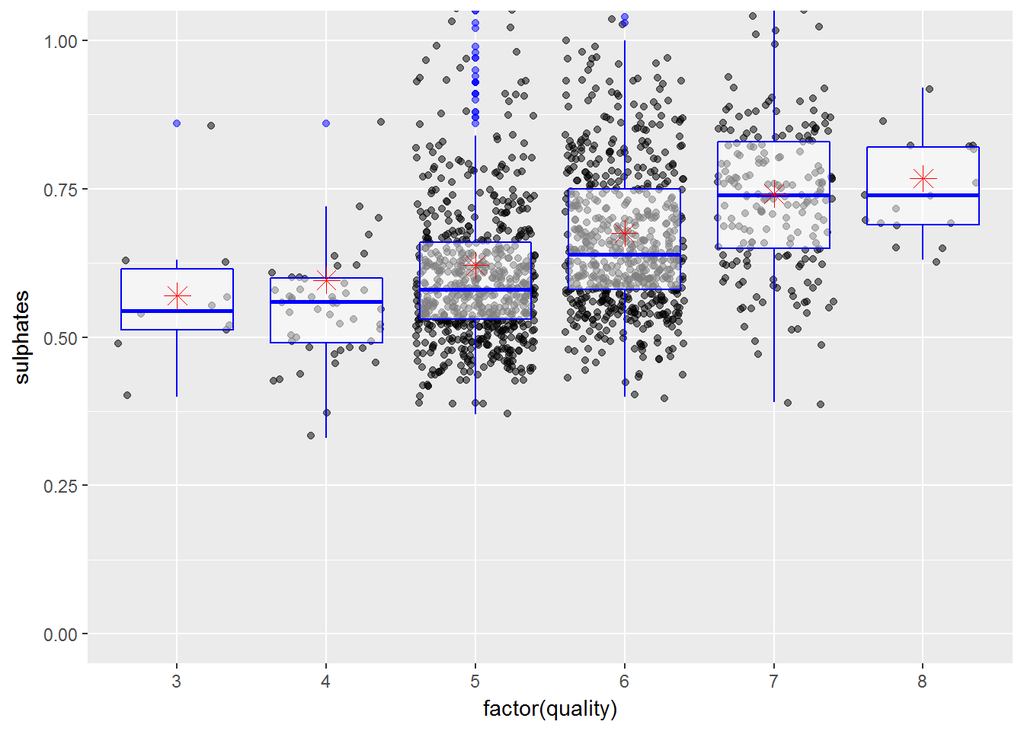

From the above point chart , it is clearly visible that quality of wine increases with the increase in quantity of sulphates.

lets check the linear model for the quantity vs sulphates.

```
##
## Call:
## lm(formula = quality ~ sulphates, data = wineQualityDataset)
##
## Residuals:
##     Min      1Q  Median      3Q     Max
## -3.2432 -0.5424  0.1102  0.4456  2.3977
##
## Coefficients:
##             Estimate Std. Error t value Pr(>|t|)
## (Intercept)  4.84775    0.07842   61.82   <2e-16 ***
## sulphates    1.19771    0.11539   10.38   <2e-16 ***
## ---
## Signif. codes:  0 '***' 0.001 '**' 0.01 '*' 0.05 '.' 0.1 ' ' 1
##
## Residual standard error: 0.7819 on 1597 degrees of freedom
## Multiple R-squared:  0.0632, Adjusted R-squared:  0.06261
## F-statistic: 107.7 on 1 and 1597 DF,  p-value: < 2.2e-16
```

Above output shows that Predictive variable sulphates is quite significant to determine the quality of the wine,but only 6.32 % of the variance in quality can be explained by the predictive variable sulphates.

lets have a look on the linear model for quality of wine and (alcohol,fixed.acidity,citric.acid and sulphates)

```
##
## Call:
## lm(formula = quality ~ alcohol + fixed.acidity + citric.acid +
##     sulphates, data = wineQualityDataset)
##
## Residuals:
##      Min       1Q   Median       3Q      Max
## -2.73513 -0.35206 -0.08876  0.51102  2.16716
##
## Coefficients:
##               Estimate Std. Error t value Pr(>|t|)
## (Intercept)    1.13822    0.21444   5.308 1.26e-07 ***
## alcohol        0.34562    0.01644  21.023  < 2e-16 ***
## fixed.acidity  0.03250    0.01348   2.411   0.0160 *
## citric.acid    0.31205    0.12479   2.501   0.0125 *
## sulphates      0.82108    0.10639   7.718 2.08e-14 ***
## ---
## Signif. codes:  0 '***' 0.001 '**' 0.01 '*' 0.05 '.' 0.1 ' ' 1
##
## Residual standard error: 0.6831 on 1594 degrees of freedom
## Multiple R-squared:  0.2862, Adjusted R-squared:  0.2844
## F-statistic: 159.8 on 4 and 1594 DF,  p-value: < 2.2e-16
```

after commbining all the four indenpendent variable, multiple r-squared values has been improved to 28.62 % , it conveys that 28.62 % of the variance in the quality of wine can be explained by these four independent variables.

At last i want to look at the linear model for the quality vs all the independent variable available in dataset.

```
##
## Call:
## lm(formula = quality ~ ., data = wineQualityDataset)
##
## Residuals:
##      Min       1Q   Median       3Q      Max
## -1.93837 -0.19283 -0.00736  0.15078  1.06060
##
## Coefficients: (1 not defined because of singularities)
##                        Estimate Std. Error t value Pr(>|t|)
## (Intercept)          12.3454186 11.9551778   1.033 0.301929
## fixed.acidity         0.0043565  0.0146500   0.297 0.766220
## volatile.acidity     -0.4296792  0.0694315  -6.189 7.72e-10 ***
## citric.acid          -0.0098927  0.0831706  -0.119 0.905334
## residual.sugar        0.0065844  0.0084631   0.778 0.436680
## chlorides            -0.7041108  0.2374169  -2.966 0.003065 **
## free.sulfur.dioxide  -0.0010079  0.0012285  -0.820 0.412076
## total.sulfur.dioxide  0.0006886  0.0004168   1.652 0.098700 .
## density              -7.2884399 12.2026963  -0.597 0.550405
## pH                   -0.2260489  0.1082278  -2.089 0.036899 *
## sulphates             0.2328535  0.0655436   3.553 0.000393 ***
## alcohol               0.0681095  0.0153576   4.435 9.85e-06 ***
## bound.sulfur.dioxide         NA         NA      NA       NA
## qualityCut(5,7]       1.2055952  0.0218484  55.180  < 2e-16 ***
## qualityCut(7,10]      2.8141693  0.0907428  31.013  < 2e-16 ***
## ---
## Signif. codes:  0 '***' 0.001 '**' 0.01 '*' 0.05 '.' 0.1 ' ' 1
##
## Residual standard error: 0.3655 on 1585 degrees of freedom
## Multiple R-squared:  0.7968, Adjusted R-squared:  0.7952
## F-statistic: 478.2 on 13 and 1585 DF,  p-value: < 2.2e-16
```

```
##
## Call:
## lm(formula = quality ~ volatile.acidity + chlorides + total.sulfur.dioxide +
##     alcohol + fixed.acidity + citric.acid + sulphates, data = wineQualityDataset)
##
## Residuals:
##      Min       1Q   Median       3Q      Max
## -2.72028 -0.37289 -0.06422  0.45556  2.01920
##
## Coefficients:
##                        Estimate Std. Error t value Pr(>|t|)
## (Intercept)           2.6516821  0.2402263  11.038  < 2e-16 ***
## volatile.acidity     -1.1733907  0.1177349  -9.966  < 2e-16 ***
## chlorides            -1.5757580  0.4080225  -3.862 0.000117 ***
## total.sulfur.dioxide -0.0019662  0.0005278  -3.725 0.000202 ***
## alcohol               0.2876488  0.0170070  16.914  < 2e-16 ***
## fixed.acidity         0.0367162  0.0136220   2.695 0.007105 **
## citric.acid          -0.2030352  0.1452195  -1.398 0.162270
## sulphates             0.8877424  0.1108192   8.011 2.18e-15 ***
## ---
## Signif. codes:  0 '***' 0.001 '**' 0.01 '*' 0.05 '.' 0.1 ' ' 1
##
## Residual standard error: 0.6502 on 1591 degrees of freedom
## Multiple R-squared:  0.3546, Adjusted R-squared:  0.3518
## F-statistic: 124.9 on 7 and 1591 DF,  p-value: < 2.2e-16
```

It visiualize the variance in quality because of newly found significant variable.

following are the newly found significant variables.

lets visiualize quality vs volatile.acidity first.

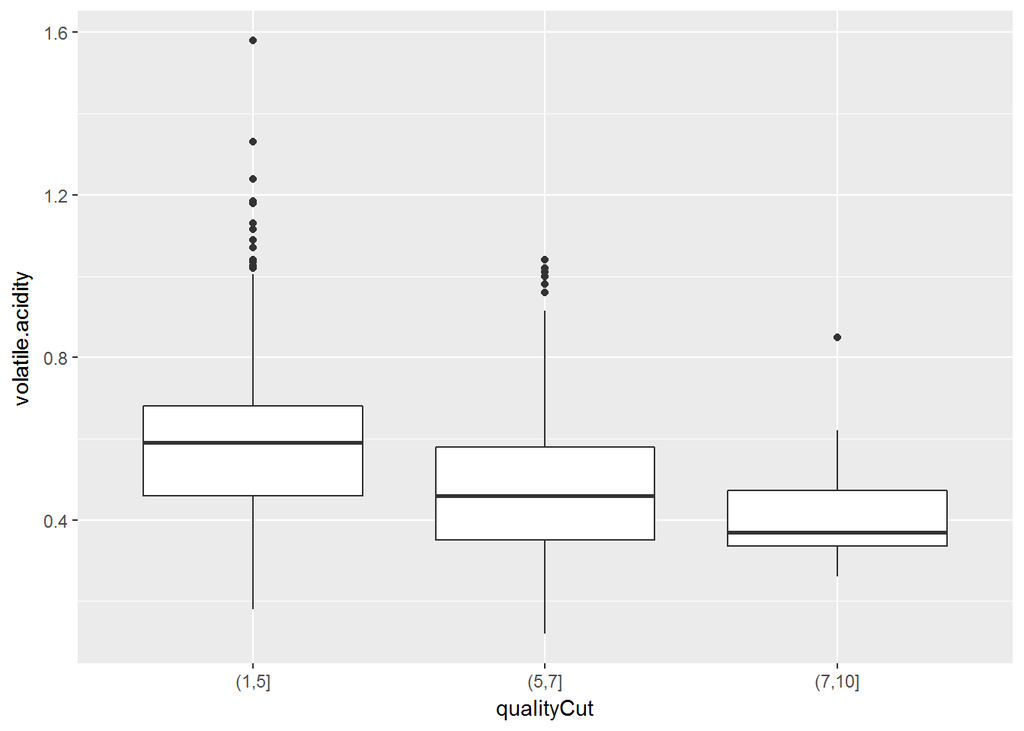

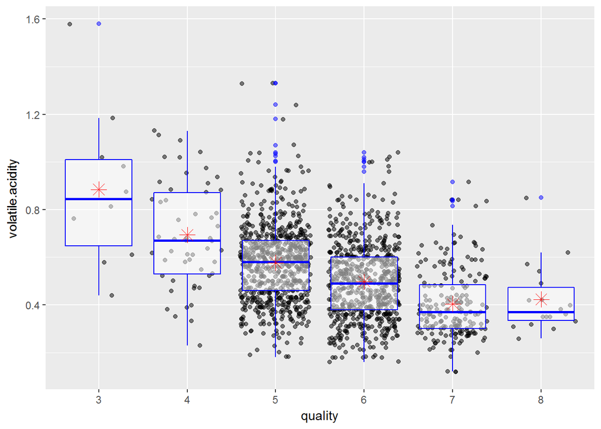

It seems there is negative correlation between quality vs volatile.acidity, As the volatile.acidity increase the quality of wine start getting decreases.

lets move the our analysis on the next pair Chlorides vs quality of wine.

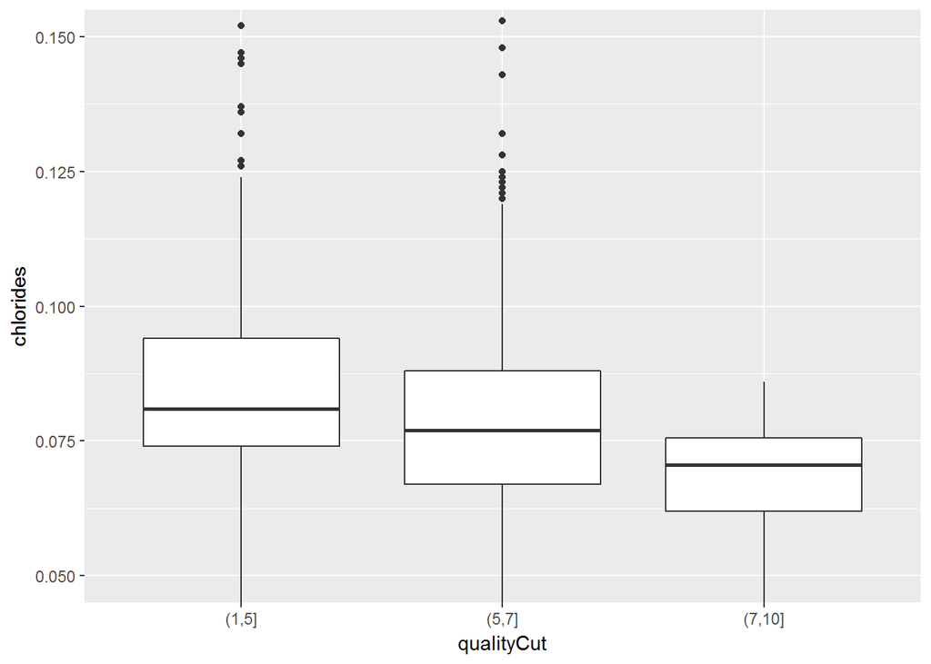

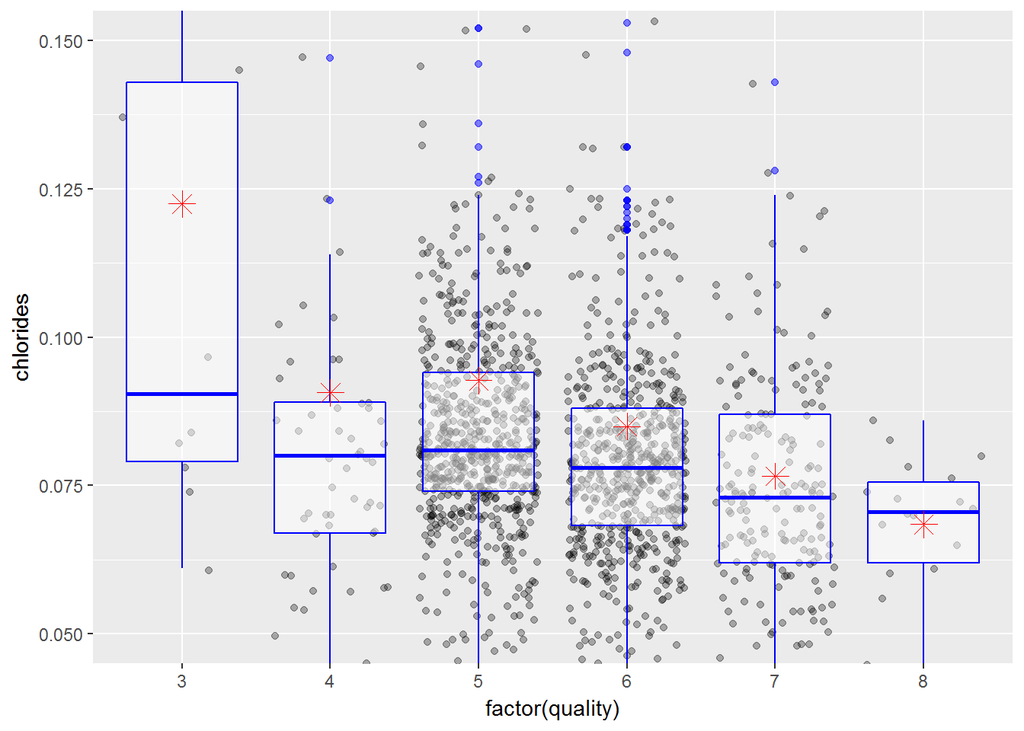

Again it seems that negative correlation between quality vs chlorides, As the chlorides increase the quality of wine start getting decreases.

now lets move to last pair of newly identified independent variable and responsive variable.

total.sulfur.dioxide vs quality

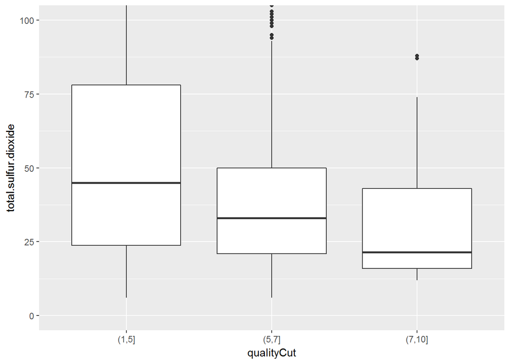

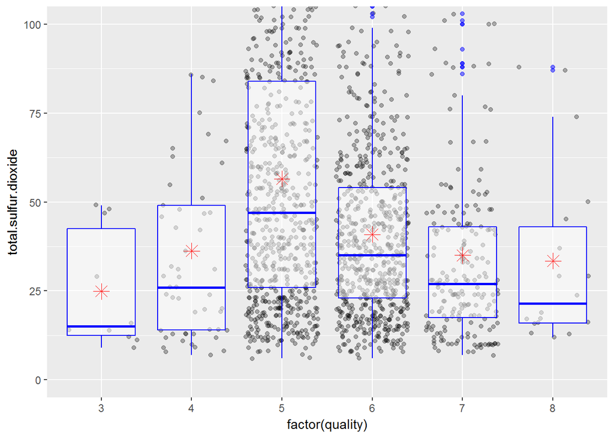

After analysing the quality of wine on different predictor variable it is vary cleary that the quality of wine cannot be determine by any one predictor variable but group of variables.

initially we have also identifed that there is moderate co-relation between fixed.acidity and density.

lets visualize it.

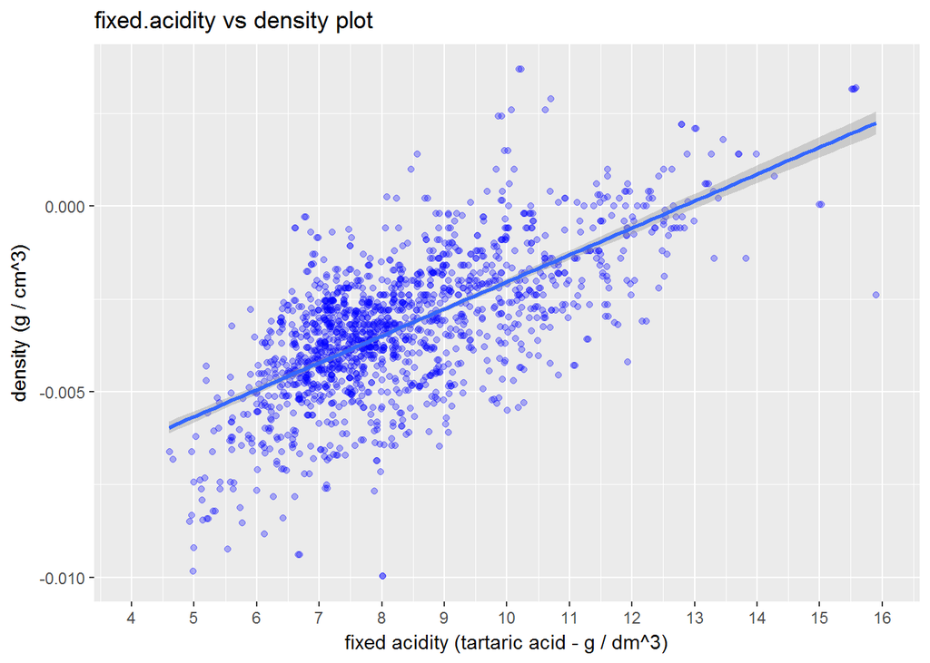

As plotted, with increase in the fixed.acidity values the density of wine is also increases.

lets put these two variable in the linear model.

```
##
## Call:
## lm(formula = density ~ fixed.acidity, data = wineQualityDataset)
##
## Residuals:
##        Min         1Q     Median         3Q        Max
## -0.0064452 -0.0007700  0.0000738  0.0009434  0.0055816
##
## Coefficients:
##                Estimate Std. Error t value Pr(>|t|)
## (Intercept)   9.907e-01  1.716e-04 5774.70   <2e-16 ***
## fixed.acidity 7.242e-04  2.018e-05   35.88   <2e-16 ***
## ---
## Signif. codes:  0 '***' 0.001 '**' 0.01 '*' 0.05 '.' 0.1 ' ' 1
##
## Residual standard error: 0.001405 on 1597 degrees of freedom
## Multiple R-squared:  0.4463, Adjusted R-squared:  0.4459
## F-statistic:  1287 on 1 and 1597 DF,  p-value: < 2.2e-16
```

44.63% of variance in density is explained by the change in the quality of fixed.acidity.

# Bivariate Analysis:

### Talk about some of the relationships you observed in this part of the

### investigation. How did the feature(s) of interest vary with other features in

### the dataset?

We have observed two type of relationship between the responsive variable and the predictive variables. 1. Positively co-related. 2. Negatively co-related.

Following are the features with shows that there is positive co-relation between quality of wine and them.

1. Alcohol.
2. Fixed.acidity.
3. citric.acid.
4. sulphates.

but all the variable combined were only able to explain 28 % of variance in quality of wine.

here are the some features which have the negative co-realtion with quality.

1. volatile.acidity.
2. total.sulphur.dioxide.
3. chloride.

all the positive and negative co-related feature in combination can explain the 35% of variance in the quality of wine.

### Did you observe any interesting relationships between the other features

Yes, between fixed.acidity and density they are moderately co-related with each other

### What was the strongest relationship you found?

After analysing the response variable quality against the different independent variable.it seems that quality of wine is best explained by the number of variable not a single variable. still we have figure out single predictor variable that explain the variance on quality of wine best then it is alcohol which explain around 23 % of variance in quality of wine.

# Multivariate Plots Section

Now we are done with the univariate and bivariate analysis. Now look at how the multiple variable effect each other.

lets use our bivariate analysis for base of multivariate analysis.

1. quality vs alcohol vs fixed acidity.
2. quality vs alcohol vs citric.acid.
3. quality vs alcohol vs sulphate.
4. quality vs alcohol vs volatile.acidity.
5. quality vs alcohol vs total.sulphur.dioxide.
6. quality vs alcohol vs chloride.
7. quality vs alcohol vs ph.
8. Alchol vs citric.acid vs sulphate vs quality.
9. total.sulphur.dioxide vs chloride vs volatile.acidity vs quality.

lets start with quality vs alcohol vs fixed acidity.

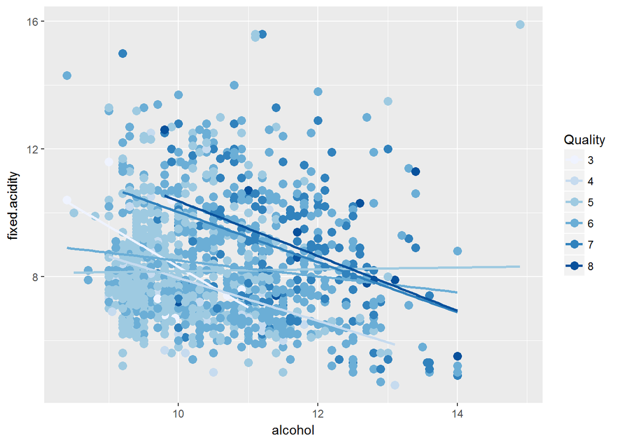

```
## wineQualityDataset$qualityCut: (1,5]
##    Min. 1st Qu.  Median    Mean 3rd Qu.    Max.
##   8.400   9.400   9.700   9.926  10.300  14.900
## --------------------------------------------------------
## wineQualityDataset$qualityCut: (5,7]
##    Min. 1st Qu.  Median    Mean 3rd Qu.    Max.
##    8.40   10.00   10.80   10.83   11.60   14.00
## --------------------------------------------------------
## wineQualityDataset$qualityCut: (7,10]
##    Min. 1st Qu.  Median    Mean 3rd Qu.    Max.
##    9.80   11.32   12.15   12.09   12.88   14.00
```

more the alcohol is better then quality of wine. As for the 7,10 segment both min and mean value of alcohol are on higher side.

```
## wineQualityDataset$qualityCut: (1,5]
##    Min. 1st Qu.  Median    Mean 3rd Qu.    Max.
##   4.600   7.100   7.800   8.142   8.900  15.900
## --------------------------------------------------------
## wineQualityDataset$qualityCut: (5,7]
##    Min. 1st Qu.  Median    Mean 3rd Qu.    Max.
##   4.700   7.100   8.000   8.472   9.600  15.600
## --------------------------------------------------------
## wineQualityDataset$qualityCut: (7,10]
##    Min. 1st Qu.  Median    Mean 3rd Qu.    Max.
##   5.000   7.250   8.250   8.567  10.230  12.600
```

same here for the fixed.acidity both the minimum and mean values are on higher side.

lets visualize quality vs alcohol vs citric.acid

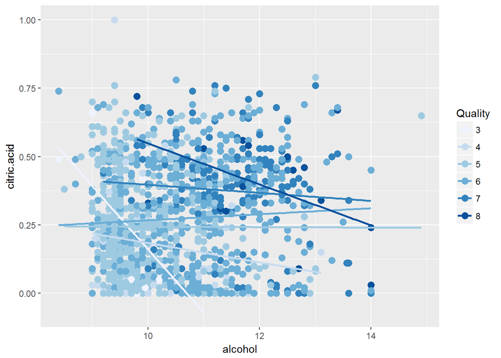

The above plot looks similar to quality vs alcohol vs fixed.acidity.